# Wine quality

Yoann Boget, Florian Hochstrasser

29 May 2018

# Introduction

## Scope

### Goal

Find the method that performs best in predicting a wine of good quality

**i.e. the one that has the best negative predicted value**

### Approach

Compare GLM, decision trees, neural networks and random forests

# Exploratory Data Analysis

## Data structure

- 1599 observations
- Explanatory
  - 11 variables, all continuous
  - Describe physiochemical properties
  - Value ranges: 1e-1 to 1e2
- Response: Categorical variable quality, coded 1 … 7
  - Recoded into two levels: 1 … 6: poor, ≥ 7: good

## Response

- Very unbalanced

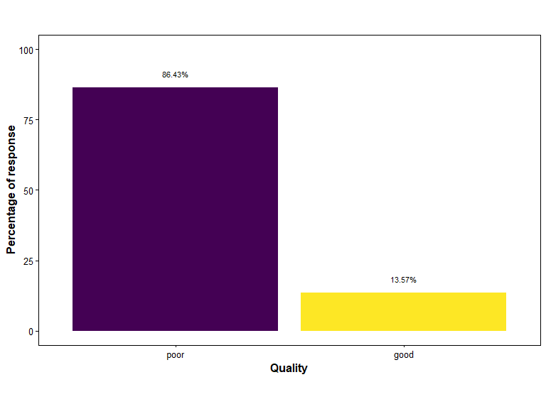

## Explanatory Variables

- Important: volatile.acidity, sulphates, alcohol

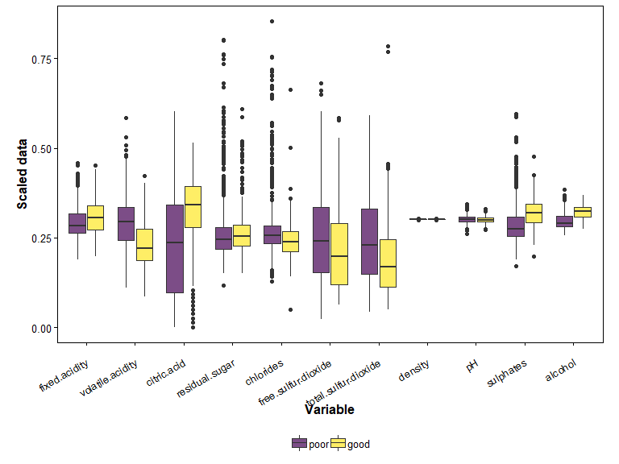

## Correlations

- acidity / pH (quite obvious)
- free / total sulfur dioxide (also, unsurprising)
- density ↔ sugar / acidity / alcohol %rarr; reasonable (molecule weights)

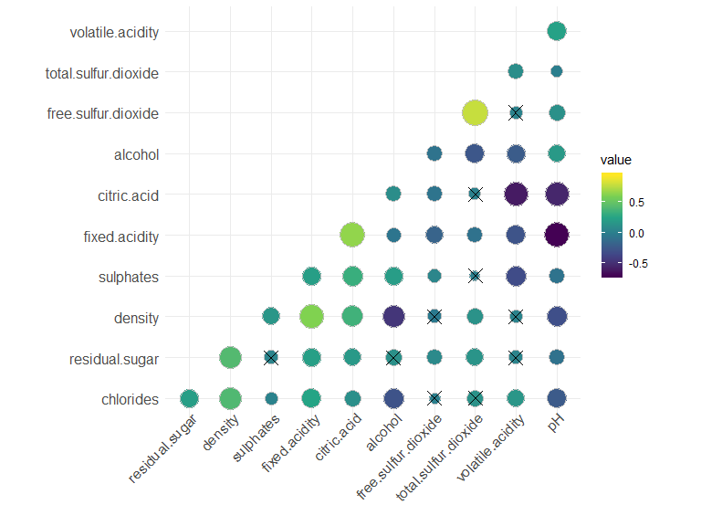

## PCA

[interactive chart not shown]

# Approaches

## Sample

- The same training / test data was used for all methods studied
- Drawn with `caret::createDataPartition`
  - 70% of data for training, 30% for testing

```r
table(wine.training$qual)
```

```
##
## poor good
##  968  152
```

```r
table(wine.test$qual)
```

```
##
## poor good
##  414   65
```

## GLM

```
##
## Call:
## glm(formula = qual ~ ., family = "binomial", data = wine.training)
##
## Deviance Residuals:
##     Min       1Q   Median       3Q      Max
## -2.0926  -0.4201  -0.2235  -0.1295   3.0515
##
## Coefficients:
##                        Estimate Std. Error z value Pr(>|z|)
## (Intercept)           2.391e+02  1.294e+02   1.848  0.06467 .
## fixed.acidity         3.084e-01  1.513e-01   2.038  0.04154 *
## volatile.acidity     -2.741e+00  9.513e-01  -2.881  0.00396 **
## citric.acid          -5.011e-02  1.045e+00  -0.048  0.96176
## residual.sugar        2.283e-01  8.188e-02   2.788  0.00531 **
## chlorides            -1.087e+01  5.098e+00  -2.132  0.03302 *
## free.sulfur.dioxide   1.143e-02  1.361e-02   0.840  0.40109
## total.sulfur.dioxide -1.303e-02  5.145e-03  -2.533  0.01131 *
## density              -2.517e+02  1.322e+02  -1.903  0.05705 .
## pH                   -7.059e-01  1.231e+00  -0.573  0.56636
## sulphates             3.456e+00  6.242e-01   5.537 3.07e-08 ***
## alcohol               8.326e-01  1.627e-01   5.118 3.09e-07 ***
## ---
## Signif. codes:  0 '***' 0.001 '**' 0.01 '*' 0.05 '.' 0.1 ' ' 1
##
## (Dispersion parameter for binomial family taken to be 1)
##
##     Null deviance: 889.52  on 1119  degrees of freedom
## Residual deviance: 608.19  on 1108  degrees of freedom
## AIC: 632.19
##
## Number of Fisher Scoring iterations: 6
```

## GLM Comparison

With cutoff at 0.5, accuracy: 0.875

|  | poor | good |
| --- | --- | --- |
| poor | 394 | 40 |
| good | 20 | 25 |

With cutoff at 0.7, accuracy: 0.875

|  | poor | good |
| --- | --- | --- |
| poor | 409 | 55 |
| good | 5 | 10 |

With cutoff at 0.1, accuracy: 0.720

|  | poor | good |
| --- | --- | --- |
| poor | 286 | 6 |
| good | 128 | 59 |

## Decision tree

```r
cp.dectree <- 0.00002
form <- as.formula(qual~.)

control <- trainControl(method = "repeatedcv",
                        number = 10,
                        repeats = 10,
                        classProbs=TRUE,
                        sampling="up")

set.seed(seed)
dectree.caret <- train(form,
                       data=wine.training,
                       cp = cp.dectree,
                       method="rpart",
                       trControl=control)
```

Important variables were:

|  | Importance |
| --- | --- |
| alcohol | 297.65506 |
| volatile.acidity | 87.01844 |
| citric.acid | 73.74184 |

## Pruned decision tree

- A size 3 tree was chosen by caret as the best fit.
  - Model selection based on *Accuracy*

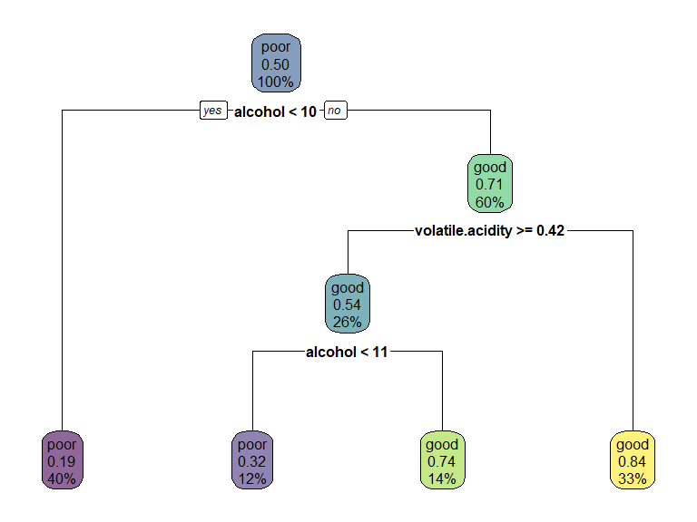

## Neural network

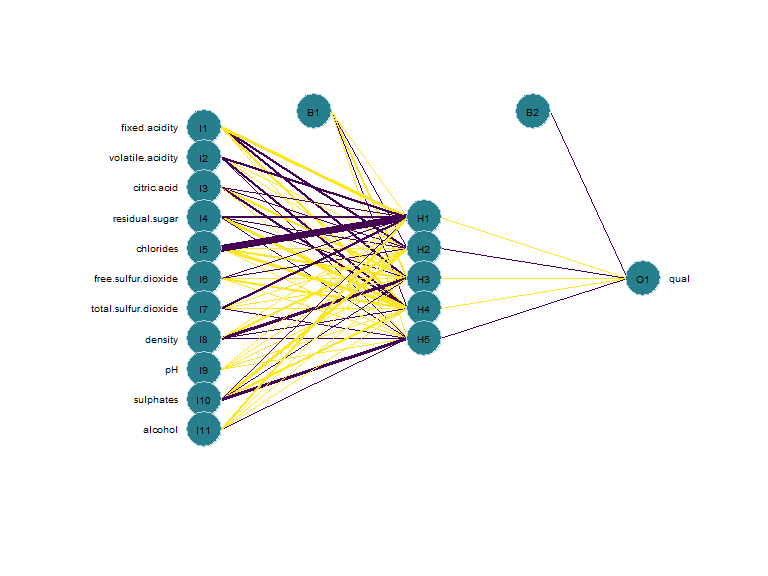

## Random forest - training settings

- Fitted using `caret::train` again

```r
wine.rf.caret <- caret::train(qual~.,
                         data=wine.training,
                         method="rf",
                         trace=T,
                         ntree = 1000,
                         #tuneGrid = data.frame(mtry = 3),
                         trControl=trainControl(
                             method="cv",
                             number=10,
                             sampling = "up"))
```

## Random forest - results

After training with 1000 trees, reduced to 600 because error stabilized there

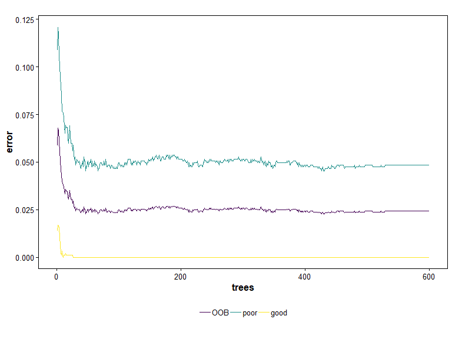

The fitted forest is very good at predicting good wines, with an error rate of 0.0.

|  | poor | good | class.error |
| --- | --- | --- | --- |
| poor | 921 | 47 | 0.0485537 |
| good | 0 | 968 | 0.0000000 |

This was not the case for the test set:

|  | poor | good |
| --- | --- | --- |
| poor | 382 | 17 |
| good | 32 | 48 |

# Conclusions

## Result comparison

- Neg. Pred. Value: That’s what we want to maximize. When we predict a wine as good, we want it to be good.

|  | GLM | GLM cutoff 0.7 | GLM cutoff 0.1 | Decisison Tree | Random Forest | Neural Network |
| --- | --- | --- | --- | --- | --- | --- |
| Neg Pred Value | 0.556 | 0.667 | 0.316 | 0.358 | 0.600 | 0.398 |
| Accuracy | 0.875 | 0.875 | 0.720 | 0.777 | 0.898 | 0.810 |
| Sensitivity | 0.952 | 0.988 | 0.691 | 0.771 | 0.923 | 0.814 |
| Specificity | 0.385 | 0.154 | 0.908 | 0.815 | 0.738 | 0.785 |

Interpretation of the confusion matrix:

|  | reality poor | reality good |
| --- | --- | --- |
| poor | TP | FP |
| good | FN | TN |